# Intro to R - Lab 4 using ggplot2

Jonathan

Tue Feb 20 12:38:23 2018

## Exercise 1

Read in the data

```r
goats = read.csv("http://www.massey.ac.nz/~jcmarsha/rcourse/goatsdata1.csv")
```

Load the ggplot2 library. If you haven’t already, install it via the packages menu in RStudio (bottom right)

```r
library(ggplot2)
```

Now plot - just the data first

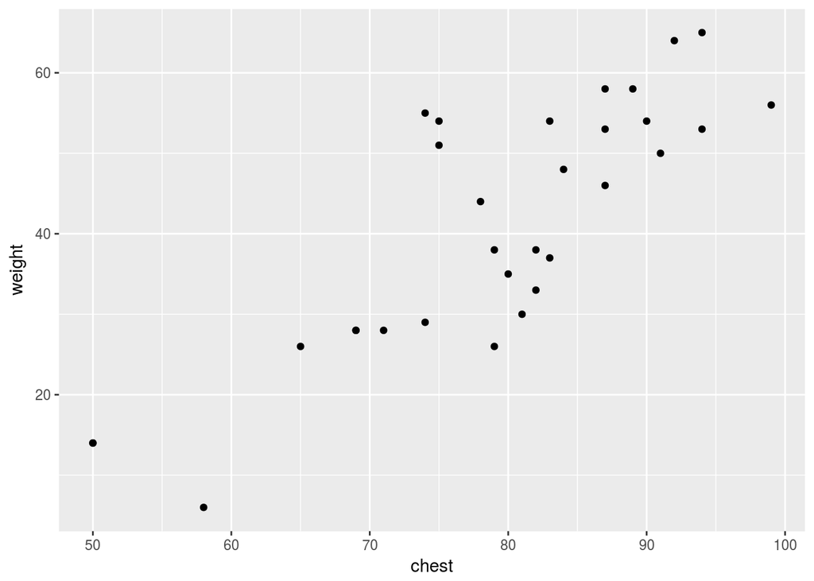

```r
ggplot(goats, aes(x=chest, y=weight)) +
  geom_point()
```

Use a different plotting symbol (shape) and change the axis labels

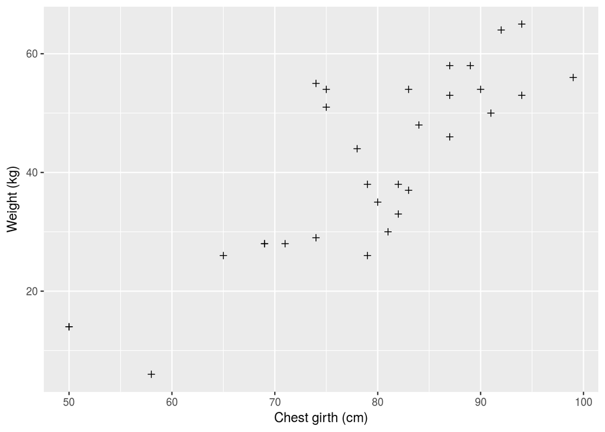

```r
ggplot(goats, aes(x=chest, y=weight)) +
  geom_point(shape=3) +
  xlab("Chest girth (cm)") +
  ylab("Weight (kg)")
```

Colour by gender. Note that because gender is numeric, it will produce a colour scale rather than a discrete colour palette

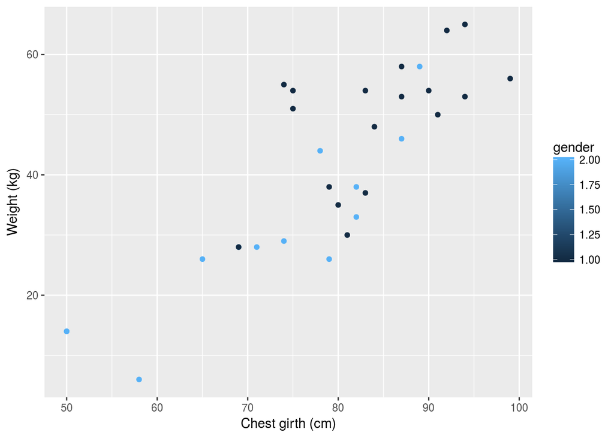

```r
ggplot(goats, aes(x=chest, y=weight, col=gender)) +
  geom_point() +
  xlab("Chest girth (cm)") +
  ylab("Weight (kg)")
```

We can switch gender to a `factor` to get a discrete colour palette

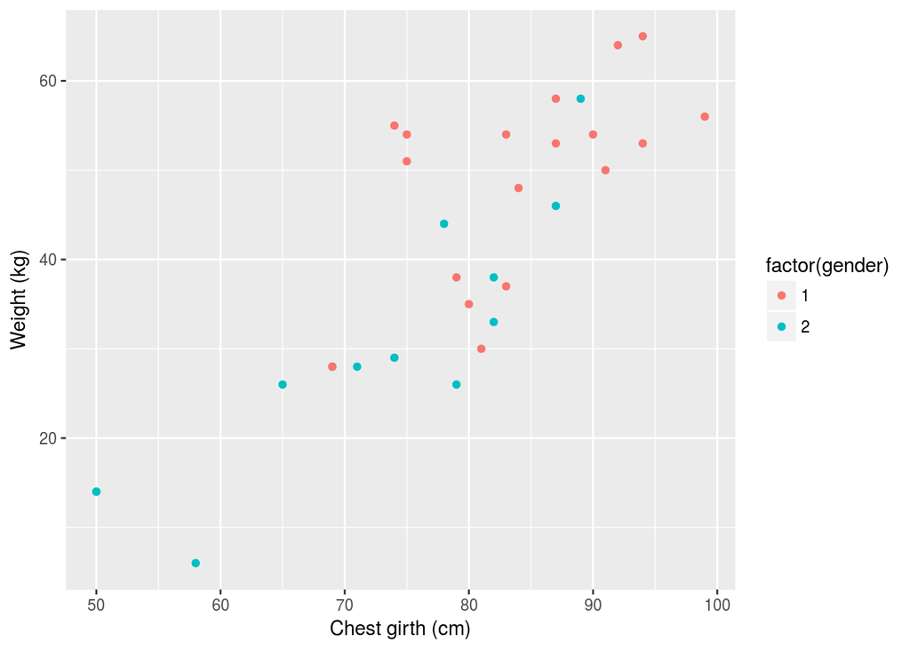

```r
ggplot(goats, aes(x=chest, y=weight, col=factor(gender))) +
  geom_point() +
  xlab("Chest girth (cm)") +
  ylab("Weight (kg)")
```

Modifying the legend is done by using `scale_color_discrete` This is because it is a scale (an aesthetic always has a scale) and that scale is for color (rather than x, or y) and it is discrete.

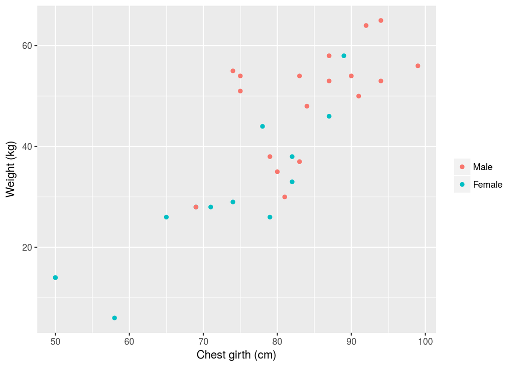

```r
ggplot(goats, aes(x=chest, y=weight, col=factor(gender))) +
  geom_point() +
  xlab("Chest girth (cm)") +
  ylab("Weight (kg)") +
  scale_color_discrete("", labels=c("Male", "Female"))
```

Note that if we’d labelled things in the `data.frame` sensibly, we wouldn’t need to do this - let’s create a new factor column with a fixed up version of Gender. To do this we convert to a factor, and specify the (existing) levels and what we want them labelled:

```r
goats$Gender = factor(goats$gender, levels = c(1,2), labels=c("Male", "Female"))
```

Now the plot is simpler. In general, the advice is to keep things in the data.frame using sensible labels. These may not be what ends up on a plot (as we can change that if we want as above), but there is no reason to use 1 and 2 if Male and Female make more sense!

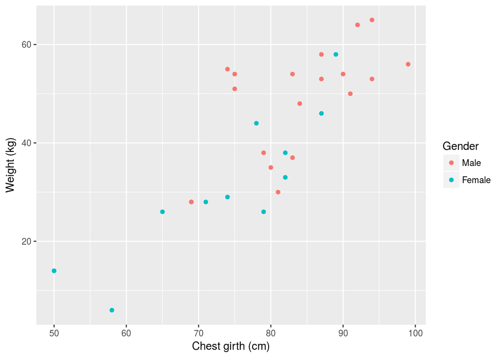

```r
ggplot(goats, aes(x=chest, y=weight, col=Gender)) +
  geom_point() +
  xlab("Chest girth (cm)") +
  ylab("Weight (kg)")
```

We can change the x variable to location. Note that ggplot2 doesn’t change the plot type, as that is defined by the geometries we choose, and we’ve specified `geom_point` here:

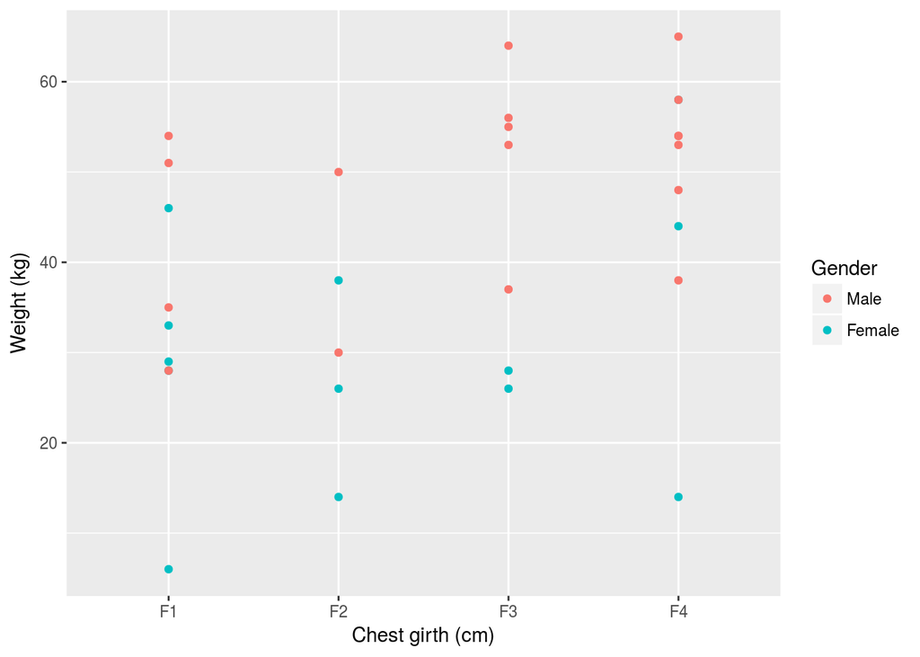

```r
ggplot(goats, aes(x=location, y=weight, col=Gender)) +
  geom_point() +
  xlab("Chest girth (cm)") +
  ylab("Weight (kg)")
```

But we can change to a boxplot easy enough:

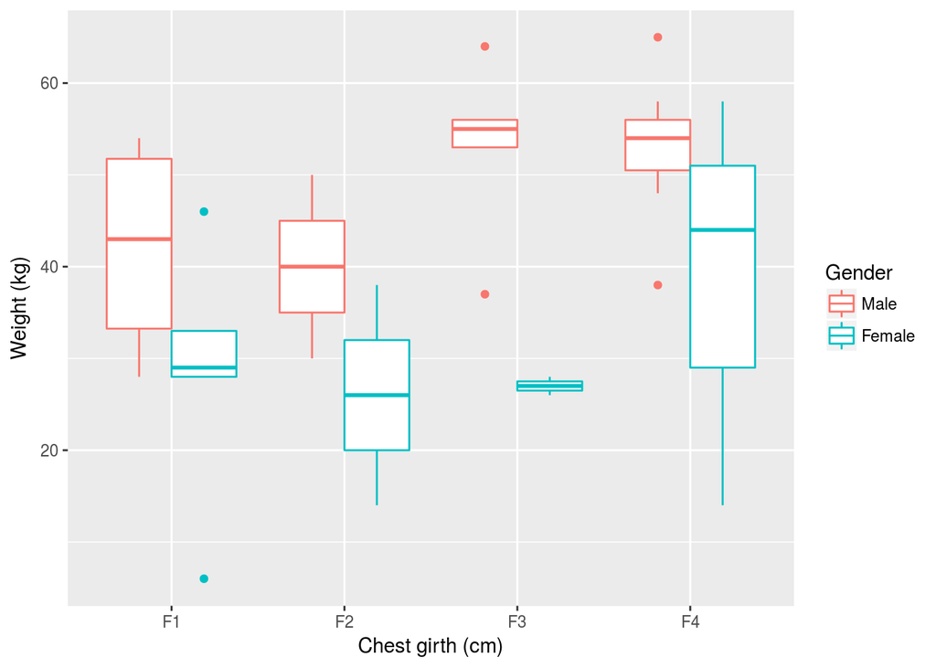

```r
ggplot(goats, aes(x=location, y=weight, col=Gender)) +
  geom_boxplot() +
  xlab("Chest girth (cm)") +
  ylab("Weight (kg)")
```

Note that as we’ve still coloured by gender, ggplot2 automatically splits all the locations by gender as well. Neat!

An alternate would be to use **small multiples** or a faceted plot:

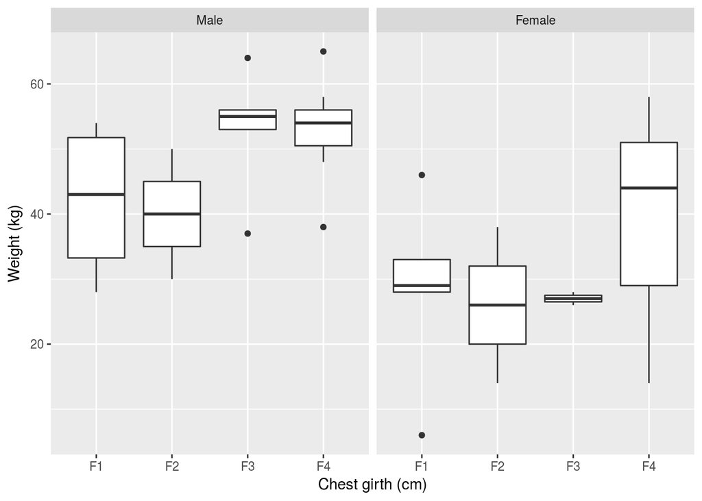

```r
ggplot(goats, aes(x=location, y=weight)) +
  geom_boxplot() +
  facet_wrap(~Gender) +
  xlab("Chest girth (cm)") +
  ylab("Weight (kg)")
```

We can do facetted histograms or histograms on top of each other as well: Note that `geom_histogram` uses the `x` aesthetic - the `y` value is computed

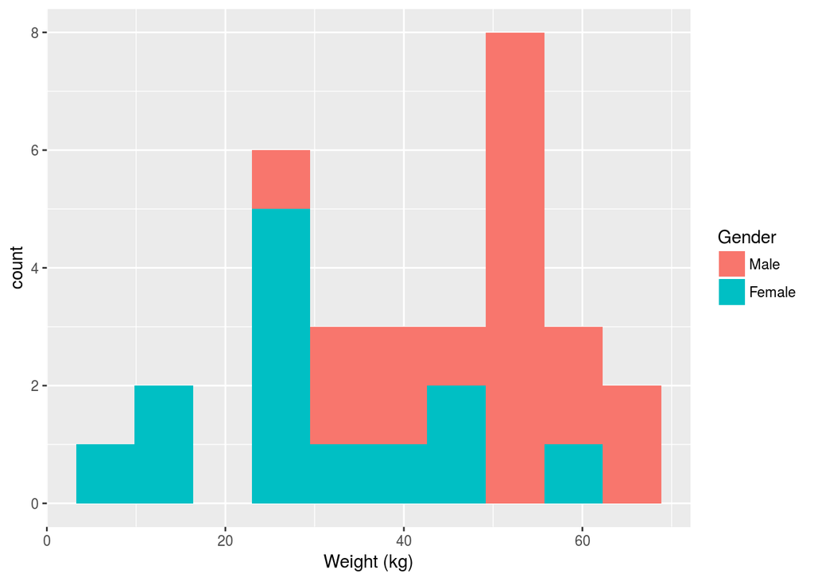

```r
ggplot(goats, aes(x=weight, fill=Gender)) +
  geom_histogram(bins=10) +
  xlab("Weight (kg)")
```

It’s easy to do side by side as well

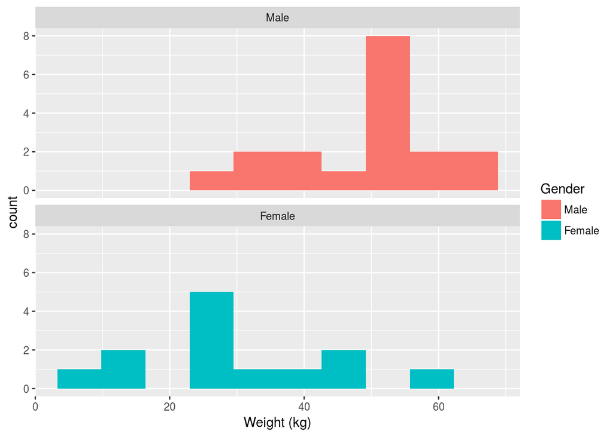

```r
ggplot(goats, aes(x=weight, fill=Gender)) +
  geom_histogram(bins=10) +
  facet_wrap(~Gender, ncol=1) +
  xlab("Weight (kg)")
```

Note the legend isn’t much use here as we already have it split up, so lets turn it off by using `guides` to set the `fill` guide to `"none"`. Just for fun, I set the theme as well

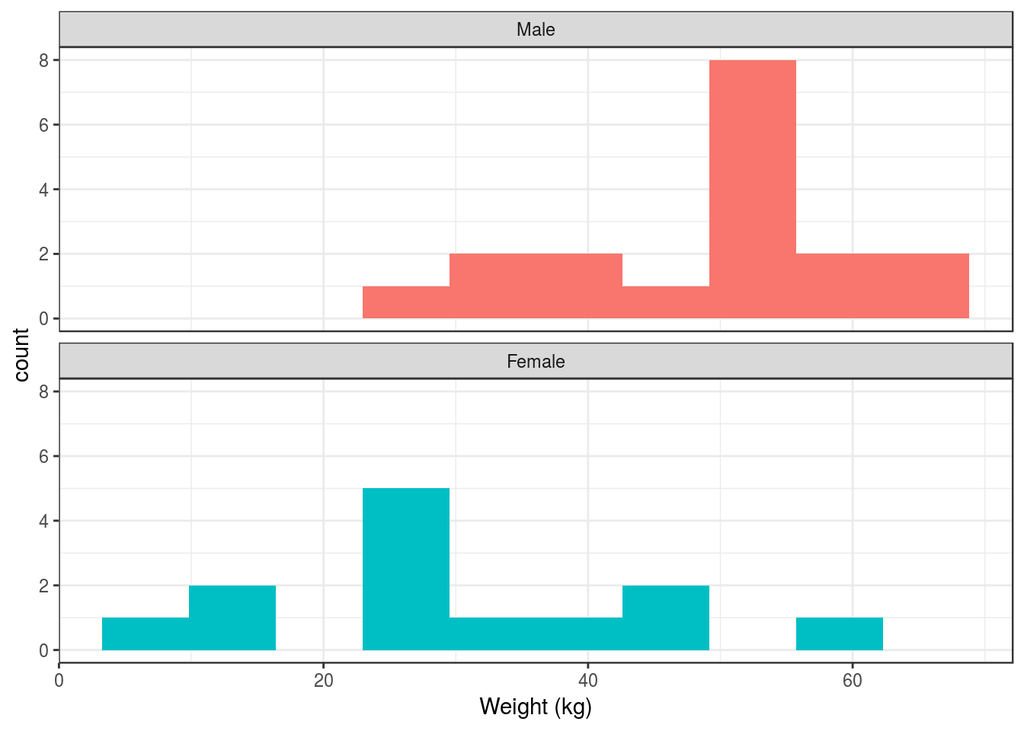

```r
ggplot(goats, aes(x=weight, fill=Gender)) +
  geom_histogram(bins=10) +
  facet_wrap(~Gender, ncol=1) +
  xlab("Weight (kg)") +
  guides(fill="none") +
  theme_bw()
```

Hopefully you see a hint of the power that ggplot2 has compared to just using base graphics. That one would be quite tricky in base. I think it would be done as follows by precomputing the histogram breaks?

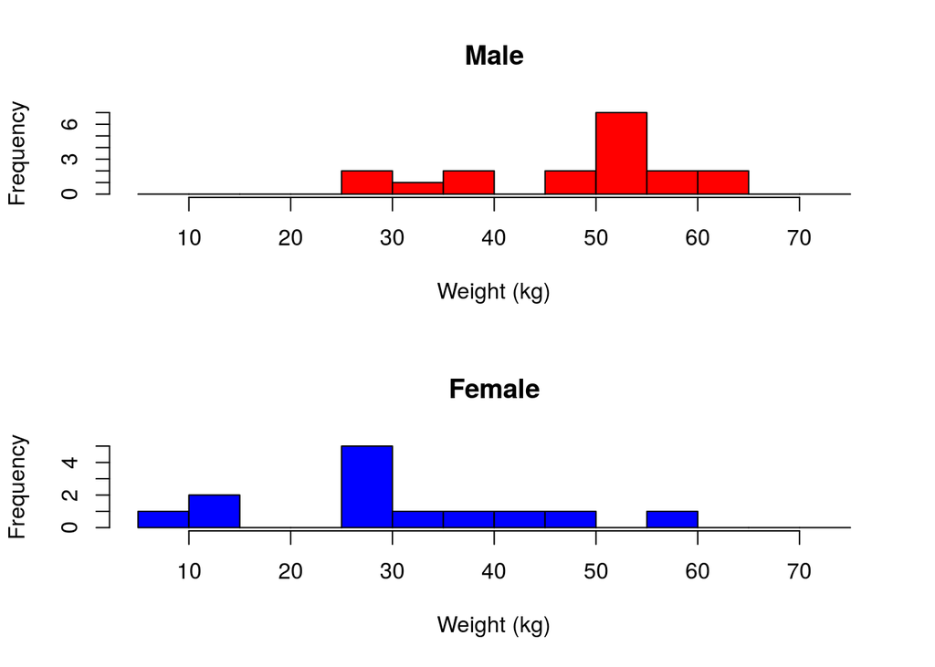

```r
par(mfrow=c(2,1))
male_weights = goats$weight[goats$gender == 1]
female_weights = goats$weight[goats$gender == 2]
breaks = seq(5,75,by=5) # breaks to use for histogram (common for both)
hist(male_weights, breaks=breaks, main="Male", xlab="Weight (kg)", col='red')
hist(female_weights, breaks=breaks, main="Female", xlab="Weight (kg)", col='blue')
```

but this has repetition of the x axis which isn’t really needed and looks a bit more naff…

## Exercise 2

ggplot2 can’t do 3D (well, it sort of can, but generally there are better tools such as `rgl` for that!) Nonetheless, you can do contour plots.

The first step here is to reshape the `volcano` data into a long data frame with x, y and z. We can use `melt` out of `reshape2` library for this, or probably by converting to a `data.frame`, adding a `y` column for the row identifier, and then using `gather` from `tidyr`.

```r
library(reshape2)
volcano3d <- melt(volcano, varnames=c('x', 'y'), value.name='z')
head(volcano3d)
```

```
##   x y   z
## 1 1 1 100
## 2 2 1 101
## 3 3 1 102
## 4 4 1 103
## 5 5 1 104
## 6 6 1 105
```

Now we can use ggplot to plot it with `geom_tile`

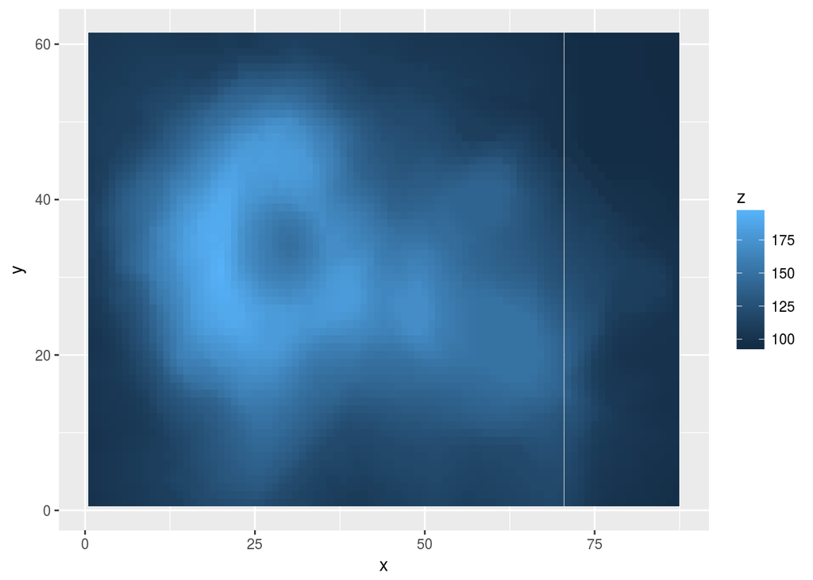

```r
ggplot(volcano3d, aes(x=x, y=y, fill=z)) +
  geom_tile()
```

We can add a contour to it with `geom_contour` by first adding a `z` aesthetic

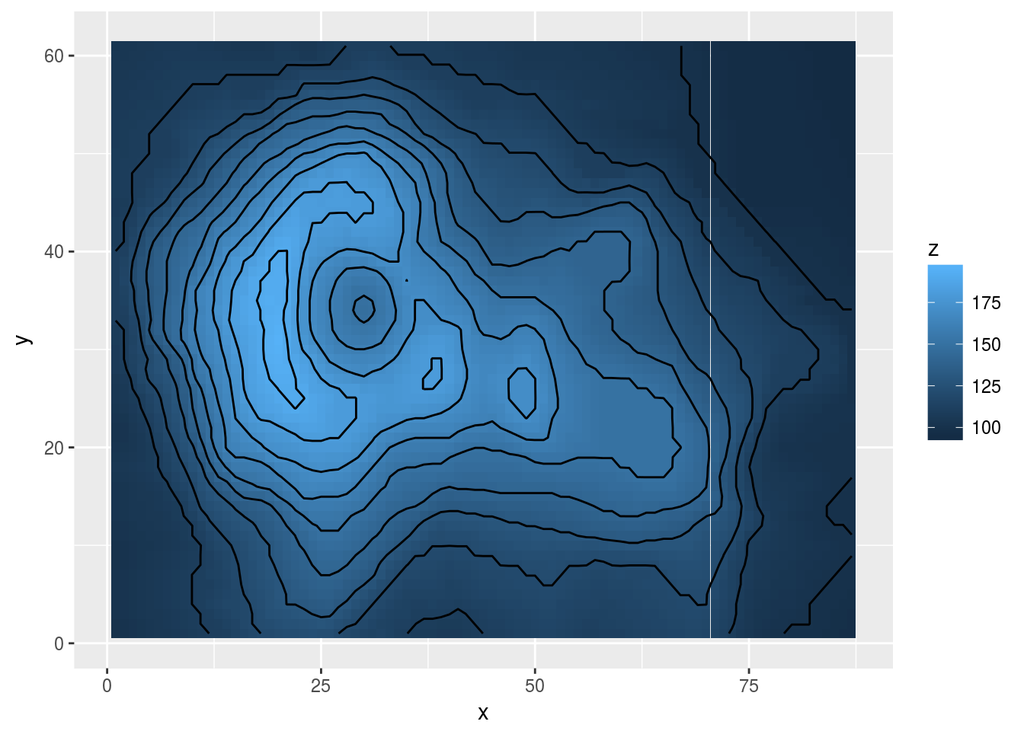

```r
ggplot(volcano3d, aes(x=x, y=y, z=z, fill=z)) +
  geom_tile() + geom_contour(col='black')
```

Colours are easy to change using `scale_fill_gradient` (we want to change a scale, it’s the fill aesthetic, and use a gradient)

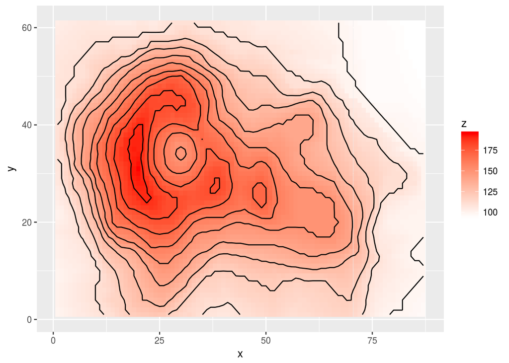

```r
ggplot(volcano3d, aes(x=x, y=y, z=z, fill=z)) +
  geom_tile() + geom_contour(col='black') +
  scale_fill_gradient(low='white', high='red')
```

We can get rid of the extra whitespace around the figure by changing the x and y scales. By default they are expanded a bit past the range of the data

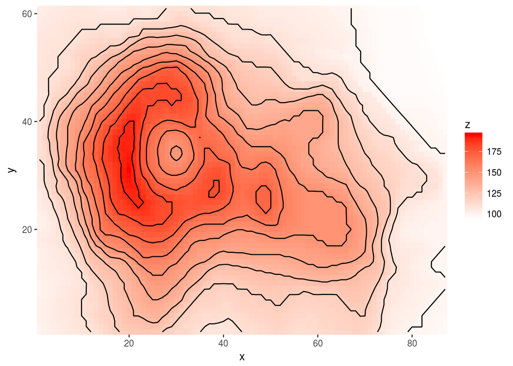

```r
ggplot(volcano3d, aes(x=x, y=y, z=z, fill=z)) +
  geom_tile() + geom_contour(col='black') +
  scale_fill_gradient(low='white', high='red') +
  scale_x_continuous(expand=c(0,0)) +
  scale_y_continuous(expand=c(0,0))
```

## Exercise 3

Plotting linear model results for simple models can be done entirely within ggplot2. You can use `geom_smooth` to add a smoother to numeric data which could be a linear model (or some other type of model, such as a loess smoother).

For data that is purely factorial like the `glaucoma` data below, you need to use another trick to combine datasets in ggplot2

Read the data in

```r
glaucoma = read.csv("http://www.massey.ac.nz/~jcmarsha/rcourse/glaucoma.csv")
```

Now let’s visualise it

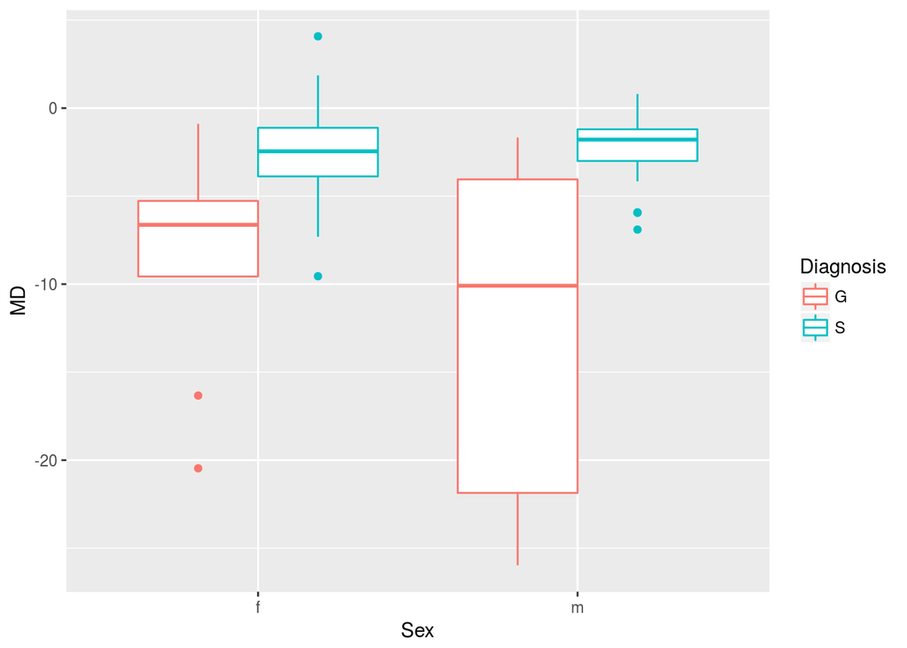

```r
ggplot(glaucoma, aes(x=Sex, y=MD, col=Diagnosis)) +
  geom_boxplot()
```

OK, now we want to fit a linear model and then plot the results on top of the boxplots. We’d first fit the linear model and create a data.frame with our predictions alongside the data used for the predictions:

```r
mod = lm(MD ~ Sex*Diagnosis, data=glaucoma)
new_data = expand.grid(Sex=c("f", "m"), Diagnosis=c("G", "S"))
pred = predict(mod, new_data, interval="confidence")
pred_df = cbind(new_data, pred)
pred_df
```

```
##   Sex Diagnosis        fit        lwr        upr
## 1   f         G  -8.472500 -11.088166 -5.8568340
## 2   m         G -12.792857 -15.589122 -9.9965926
## 3   f         S  -2.440577  -3.466526 -1.4146283
## 4   m         S  -2.241562  -3.549395 -0.9337295
```

OK, now we can do the plot by adding a `geom_errorbar` that uses the new data source. To do this we have to move the aesthetic definition into the geom rather than in the main ggplot2, as we have different aesthetics for each geom. We also must use a trick to get the error bars to ‘dodge’ correctly like the boxplot does. I found the 0.75 value just by experimentation. I think you can get it out of the ggplot object somehow though!

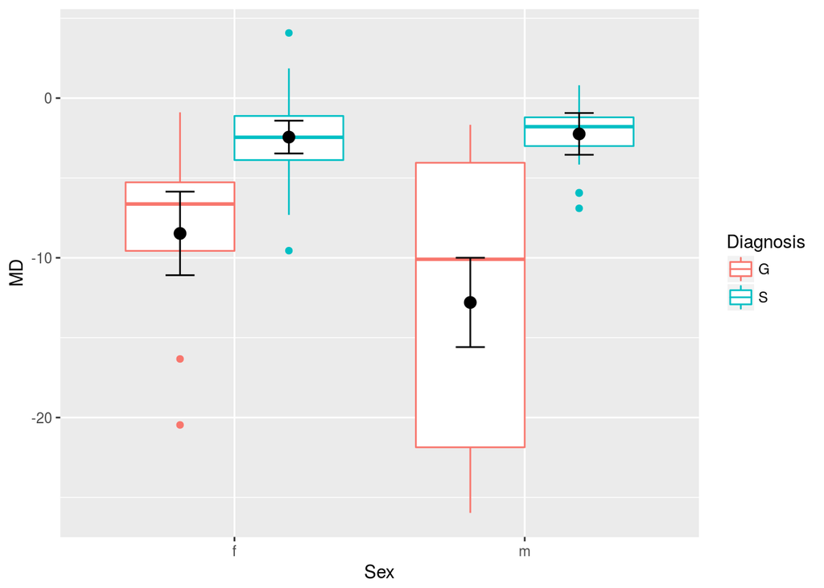

```r
ggplot() +
  geom_boxplot(aes(x=Sex, y=MD, col=Diagnosis), data=glaucoma) +
  geom_errorbar(aes(x=Sex, ymin=lwr, ymax=upr, group=Diagnosis), position = position_dodge(width=0.75),
                width=0.2, data=pred_df) +
  geom_point(aes(x=Sex, y=fit, group=Diagnosis), position = position_dodge(width=0.75), size=3, data=pred_df)
```

Lastly, note that `visreg` can make use of `ggplot2` when it plots by adding `gg=TRUE`. You can then do all the usual things with ggplot like add themes etc

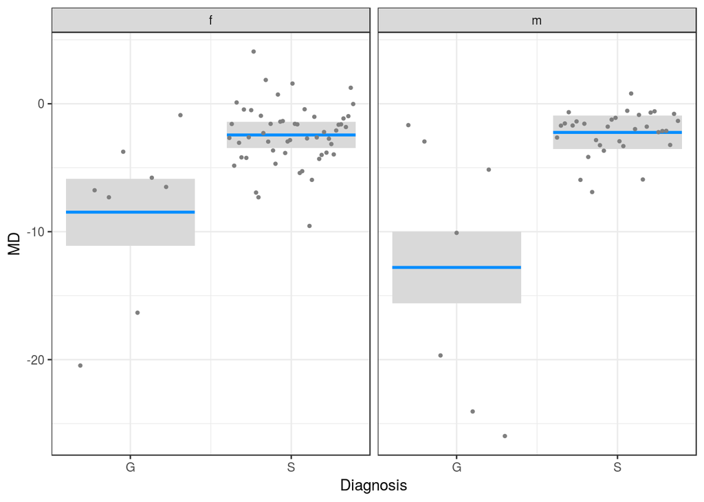

```r
library(visreg)
visreg(mod, "Diagnosis", by="Sex", gg=TRUE) +
  theme_bw()
```